# Q2 – Vitamin D, ultra-processed food (UPF) proxy, diabetes and obesity

15 十月 2026

# 1 Setup

**Before knitting:** put `AHSnpa11bp.csv` (person level) and `AHSnpa11bb.csv` (biomedical level) in the same folder as this `.Rmd` file, or change `data_dir` below. In RStudio, use *Session → Set Working Directory → To Source File Location*, then click **Knit**.

```r
pkgs <- c("dplyr", "tidyr", "ggplot2", "survey", "pROC", "car",
          "knitr", "cluster", "MASS", "rpart", "class", "splines")
missing_pkgs <- pkgs[!pkgs %in% rownames(installed.packages())]
if (length(missing_pkgs) > 0) install.packages(missing_pkgs)

library(dplyr); library(tidyr); library(ggplot2); library(survey)
library(pROC); library(knitr); library(cluster)
# MASS, rpart, class, car and splines are called with pkg:: so they don't mask dplyr::select

data_dir <- "."          # folder containing the two CSV files
out_dir  <- "q2_outputs" # tables are also saved here as CSV for the report
dir.create(out_dir, showWarnings = FALSE)
set.seed(2026)
theme_set(theme_minimal(base_size = 12))
```

## 1.1 Helper functions

```r
fmt_p <- function(p) ifelse(is.na(p), "", ifelse(p < 0.001, "<0.001", sprintf("%.3f", p)))

# Readable labels for model terms
term_labels <- c(
  "vitd3Mild"                          = "Vit D mild deficiency, 30–49 nmol/L (ref: adequate ≥50)",
  "vitd3ModSevere"                     = "Vit D moderate/severe deficiency, <30 nmol/L (ref: adequate)",
  "vitd_defDeficient"                  = "Vit D deficient, <50 nmol/L (ref: adequate)",
  "diabetesDiabetes"                   = "Diabetes (HbA1c) (ref: no diabetes)",
  "vitd_defDeficient:diabetesDiabetes" = "Interaction: Vit D deficient × Diabetes (ratio of ORs)",
  "upf10"                              = "UPF proxy, per +10 % of energy",
  "age"                                = "Age, per year",
  "sexFemale"                          = "Female (ref: male)",
  "energy_MJ"                          = "Total energy, per MJ/day",
  "pa_hours"                           = "Physical activity, per hour/week",
  "smokerEx"                           = "Ex-smoker (ref: never)",
  "smokerCurrent"                      = "Current smoker (ref: never)"
)
lab <- function(x) ifelse(x %in% names(term_labels), term_labels[x], x)

# Exponentiated coefficients with Wald CIs.
# For svyglm the t distribution uses the design degrees of freedom.
tidy_or <- function(fit) {
  s  <- summary(fit)
  ct <- s$coefficients
  df <- if (inherits(fit, "svyglm")) s$df.residual else Inf
  crit <- qt(0.975, df)
  data.frame(term = rownames(ct),
             est  = exp(ct[, 1]),
             lo   = exp(ct[, 1] - crit * ct[, 2]),
             hi   = exp(ct[, 1] + crit * ct[, 2]),
             p    = ct[, 4], row.names = NULL)
}

# Table of ORs for several fitted models (one column per model)
or_compare <- function(fits) {
  rows <- lapply(names(fits), function(m) {
    tidy_or(fits[[m]]) %>% filter(term != "(Intercept)") %>%
      transmute(term, model = m,
                value = sprintf("%.2f (%.2f–%.2f); p=%s", est, lo, hi, fmt_p(p)))
  })
  bind_rows(rows) %>%
    pivot_wider(names_from = model, values_from = value, values_fill = "—") %>%
    mutate(term = lab(term)) %>% rename(Term = term)
}

# One-line summary of a single term, for use in the text
or_txt <- function(fit, term, what = "OR") {
  r <- tidy_or(fit) %>% filter(.data$term == !!term)
  sprintf("%s = %.2f (95%% CI %.2f–%.2f, p = %s)", what, r$est, r$lo, r$hi, fmt_p(r$p))
}
p_of   <- function(fit, term) tidy_or(fit) %>% filter(.data$term == !!term) %>% pull(p)
sigtxt <- function(p) ifelse(p < 0.05, "statistically significant", "not statistically significant")

# % change in the exposure OR when confounders are added (>10% = meaningful confounding)
pct_change <- function(crude, adj, term) {
  a <- tidy_or(crude) %>% filter(.data$term == !!term) %>% pull(est)
  b <- tidy_or(adj)   %>% filter(.data$term == !!term) %>% pull(est)
  100 * (b - a) / a
}

# Unweighted glm summaries used for AIC / likelihood-ratio tests / pseudo-R2
glm_fit <- function(f, data) glm(f, data = data, family = binomial)
# McFadden pseudo-R2 = 1 - logL(model)/logL(null); for 0/1 data this equals 1 - deviance/null deviance
mcfadden <- function(fit) 1 - fit$deviance / fit$null.deviance

brier <- function(y, p) mean((y - p)^2)
mk_roc <- function(y, p) pROC::roc(response = y, predictor = p,
                                   levels = c(0, 1), direction = "<", quiet = TRUE)

# Hosmer–Lemeshow goodness-of-fit test (implemented here so no extra package is needed)
hosmer_lemeshow <- function(y, p, g = 10) {
  br  <- unique(quantile(p, probs = seq(0, 1, length.out = g + 1)))
  grp <- cut(p, br, include.lowest = TRUE)
  obs <- tapply(y, grp, sum); expd <- tapply(p, grp, sum); n <- tapply(y, grp, length)
  stat <- sum((obs - expd)^2 / (expd * (1 - expd / n)))
  df <- length(n) - 2
  c(statistic = stat, df = df, p.value = pchisq(stat, df, lower.tail = FALSE))
}

# Adjusted Rand index between two labelings (cluster vs obesity)
adj_rand <- function(a, b) {
  tab <- table(a, b); n <- sum(tab)
  sc <- sum(choose(tab, 2)); sa <- sum(choose(rowSums(tab), 2)); sb <- sum(choose(colSums(tab), 2))
  expct <- sa * sb / choose(n, 2)
  (sc - expct) / ((sa + sb) / 2 - expct)
}

save_tab <- function(df, name) write.csv(df, file.path(out_dir, paste0(name, ".csv")), row.names = FALSE)
```

# 2 Data preparation

## 2.1 Read and merge

The person file and biomedical file share the selected-person identifier `ABSPID` (one row per person in each file).

```r
bp_cols <- c("ABSHID", "ABSPID", "AGEC", "SEX", "FEMLSBC", "BMISC", "PHDCMWBC",
             "SATPER1", "PEADDSD1", "ENERGYT1", "EXLWTBC", "SMKSTAT", "NPAFINWT")
bb_cols <- c("ABSPID", "BIORESPC", "VDLCMRGT", "DIABPRVE", "NHMSPERW",
             sprintf("RPWGT%02d", 1:60))

bp <- read.csv(file.path(data_dir, "AHSnpa11bp.csv"))[, bp_cols]
bb <- read.csv(file.path(data_dir, "AHSnpa11bb.csv"))[, bb_cols]

stopifnot(!anyDuplicated(bp$ABSPID), !anyDuplicated(bb$ABSPID))
raw <- left_join(bp, bb, by = "ABSPID")
c(person_rows = nrow(bp), biomedical_rows = nrow(bb), merged = nrow(raw))
```

```
##     person_rows biomedical_rows          merged
##           12153           12153           12153
```

## 2.2 Recode variables (codes from the NNPAS Basic CURF data item list)

| Variable | Source | Coding used |
| --- | --- | --- |
| `obese` | `BMISC` | 1 if measured BMI ≥ 30; codes 0/98/99 (not applicable / not measured / not known) → missing |
| `vitd3` | `VDLCMRGT` | 1 Adequate ≥50 nmol/L, 2 Mild 30–49, 3 Moderate/severe <30; 0/8 → missing |
| `vitd_def` | `VDLCMRGT` | Deficient (<50 nmol/L) vs adequate — used for the interaction because cells are small |
| `diabetes` | `DIABPRVE` | Diabetes = 1 known or 2 newly diagnosed; No diabetes = 3 normal or 4 at risk; 0/8 → missing |
| `upf` | `SATPER1 + PEADDSD1` | % energy from saturated + trans fat + % energy from added sugars (Day 1); modelled per 10 %E |
| `age`, `sex` | `AGEC`, `SEX` | Confounders |
| Restriction | `AGEC`, `FEMLSBC` | Age 18–64; currently pregnant women (`FEMLSBC` = 2) excluded |
| Sensitivity only | `PHDCMWBC`, `ENERGYT1`, `EXLWTBC`, `SMKSTAT` | Waist-based obesity, energy, physical activity, smoking |

```r
dat <- raw %>%
  filter(AGEC >= 18, AGEC <= 64, FEMLSBC != 2) %>%
  mutate(
    BMI      = ifelse(BMISC > 0 & BMISC < 97, BMISC, NA),
    obese    = as.integer(BMI >= 30),
    obese_f  = factor(obese, 0:1, c("Not obese", "Obese")),
    age      = AGEC,
    sex      = factor(SEX, 1:2, c("Male", "Female")),
    vitd_score = ifelse(VDLCMRGT %in% 1:3, VDLCMRGT, NA),       # 1 adequate … 3 mod/severe
    vitd3    = factor(vitd_score, 1:3, c("Adequate", "Mild", "ModSevere")),
    vitd_def = factor(ifelse(is.na(vitd_score), NA, as.integer(vitd_score >= 2)),
                      0:1, c("Adequate", "Deficient")),
    diabetes = factor(ifelse(DIABPRVE %in% 1:4, as.integer(DIABPRVE <= 2), NA),
                      0:1, c("No diabetes", "Diabetes")),
    upf      = SATPER1 + PEADDSD1,
    upf10    = upf / 10,
    waist    = ifelse(PHDCMWBC > 0 & PHDCMWBC < 998, PHDCMWBC, NA),
    waist_obese = as.integer((sex == "Male" & waist >= 94) | (sex == "Female" & waist >= 80)),
    energy_MJ = ENERGYT1 / 1000,
    pa_hours  = ifelse(EXLWTBC <= 2100, EXLWTBC / 60, NA),        # 9996/9999 → missing
    smoker    = factor(case_when(SMKSTAT %in% 1:3 ~ "Current", SMKSTAT == 4 ~ "Ex",
                                 SMKSTAT == 5 ~ "Never"), levels = c("Never", "Ex", "Current"))
  )

# Analysis samples (complete cases)
d_full <- dat %>% filter(!is.na(obese), !is.na(upf))                       # UPF analysis (Person 2)
d_bio  <- d_full %>% filter(!is.na(vitd3), !is.na(diabetes), NHMSPERW > 0)  # Vit D analyses (Persons 1, 3, 4 & Week 10)

sample_flow <- data.frame(
  Step = c("Merged NNPAS records", "Aged 18–64 and not pregnant",
           "+ valid measured BMI and UPF proxy (Person 2 sample)",
           "+ valid vitamin D and HbA1c diabetes status (Persons 1, 3, 4; Week 10)"),
  n = c(nrow(raw), nrow(dat), nrow(d_full), nrow(d_bio)))
kable(sample_flow, caption = "Sample flow")
```

Sample flow

| Step | n |
| --- | --- |
| Merged NNPAS records | 12153 |
| Aged 18–64 and not pregnant | 7215 |
| + valid measured BMI and UPF proxy (Person 2 sample) | 6246 |
| + valid vitamin D and HbA1c diabetes status (Persons 1, 3, 4; Week 10) | 2617 |

## 2.3 Survey designs

Population estimates use the ABS weights. The biomedical file supplies 60 delete-a-group jackknife replicate weights (`RPWGT01–60`), which give design-based standard errors. The person file has no replicate weights, so the full-sample design uses the person weight only.

```r
des_full <- svydesign(ids = ~1, weights = ~NPAFINWT, data = d_full)
des_bio  <- svrepdesign(data = d_bio, weights = ~NHMSPERW,
                        repweights = "RPWGT[0-9]+", type = "JK1",
                        scale = 59 / 60, mse = TRUE)
```

## 2.4 Descriptive overview

```r
prev_by <- function(var, design) {
  r <- svyby(~obese, as.formula(paste0("~", var)), design, svymean, na.rm = TRUE)
  n <- table(design$variables[[var]])
  data.frame(Variable = var, Group = as.character(r[[var]]),
             n = as.integer(n[as.character(r[[var]])]),
             `Weighted obesity %` = sprintf("%.1f (SE %.1f)", 100 * r$obese, 100 * SE(r)),
             check.names = FALSE)
}
d_bio$upf_q  <- cut(d_bio$upf,  quantile(d_bio$upf,  0:4 / 4), include.lowest = TRUE, labels = paste0("Q", 1:4))
d_full$upf_q <- cut(d_full$upf, quantile(d_full$upf, 0:4 / 4), include.lowest = TRUE, labels = paste0("Q", 1:4))
des_bio  <- update(des_bio,  upf_q = d_bio$upf_q)
des_full <- update(des_full, upf_q = d_full$upf_q)

desc_tab <- bind_rows(prev_by("vitd3", des_bio), prev_by("diabetes", des_bio),
                      prev_by("sex", des_bio), prev_by("upf_q", des_full))
kable(desc_tab, caption = "Survey-weighted obesity prevalence by group (unadjusted)")
```

Survey-weighted obesity prevalence by group (unadjusted)

| Variable | Group | n | Weighted obesity % |
| --- | --- | --- | --- |
| vitd3 | Adequate | 2013 | 22.9 (SE 1.4) |
| vitd3 | Mild | 463 | 21.3 (SE 2.6) |
| vitd3 | ModSevere | 141 | 33.8 (SE 7.2) |
| diabetes | No diabetes | 2519 | 22.5 (SE 1.2) |
| diabetes | Diabetes | 98 | 47.7 (SE 7.5) |
| sex | Male | 1182 | 23.0 (SE 1.9) |
| sex | Female | 1435 | 23.8 (SE 1.4) |
| upf_q | Q1 | 1562 | 23.0 (SE 1.4) |
| upf_q | Q2 | 1561 | 23.5 (SE 1.4) |
| upf_q | Q3 | 1561 | 26.3 (SE 1.5) |
| upf_q | Q4 | 1562 | 28.0 (SE 1.5) |

```r
save_tab(desc_tab, "table1_weighted_prevalence")

kable(table(VitaminD = d_bio$vitd3, Diabetes = d_bio$diabetes),
      caption = "Cell counts: vitamin D × diabetes (why the interaction uses binary deficiency)")
```

Cell counts: vitamin D × diabetes (why the interaction uses binary deficiency)

|  | No diabetes | Diabetes |
| --- | --- | --- |
| Adequate | 1947 | 66 |
| Mild | 436 | 27 |
| ModSevere | 136 | 5 |

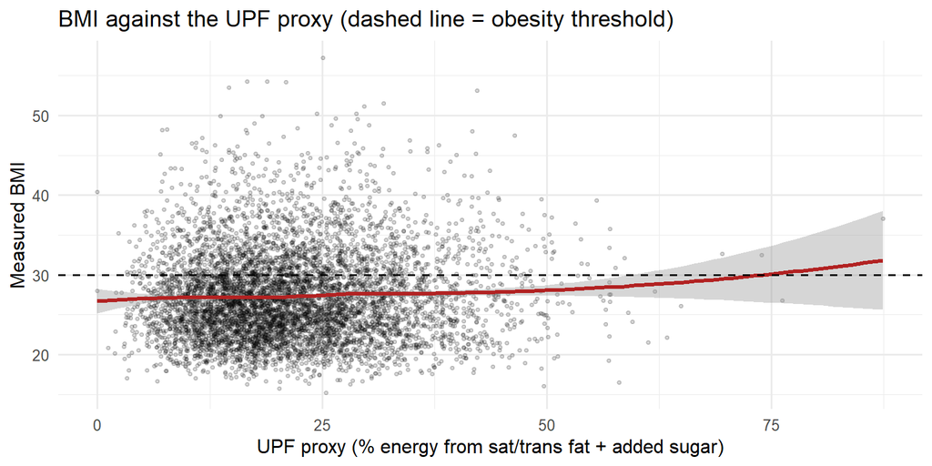

```r
ggplot(d_full, aes(upf, BMI)) +
  geom_point(alpha = 0.15, size = 0.8) +
  geom_smooth(method = "loess", se = TRUE, colour = "firebrick") +
  geom_hline(yintercept = 30, linetype = "dashed") +
  labs(x = "UPF proxy (% energy from sat/trans fat + added sugar)", y = "Measured BMI",
       title = "BMI against the UPF proxy (dashed line = obesity threshold)")
```

# 3 Week 9 – Model building and significance of the independent variables

All models are logistic regressions for `logit P(Obese = 1)`. For each person we report:

- **Survey-weighted ORs** (`svyglm`, quasibinomial, replicate-weight SEs) — the primary, population-level result;
- the **joint Wald test** for multi-level factors (`regTermTest`);
- **unweighted `glm` likelihood-ratio tests and AIC**, used for model comparison;
- the **% change in the exposure OR** after adjustment (a change of more than 10% suggests confounding by age/sex).

```r
f <- list(
  P1_crude = obese ~ vitd3,
  P1_adj   = obese ~ vitd3 + age + sex,
  P2_crude = obese ~ upf10,
  P2_adj   = obese ~ upf10 + age + sex,
  P3_crude = obese ~ vitd3 + upf10,
  P3_adj   = obese ~ vitd3 + upf10 + age + sex,
  P4_main  = obese ~ vitd_def + diabetes + upf10 + age + sex,
  P4_int   = obese ~ vitd_def * diabetes + upf10 + age + sex   # = the full model in the brief
)

# Survey-weighted fits (biomedical design for everything except Person 2 primary)
sw <- lapply(f, function(ff) svyglm(ff, design = des_bio, family = quasibinomial()))
sw$P2_crude_full <- svyglm(f$P2_crude, design = des_full, family = quasibinomial())
sw$P2_adj_full   <- svyglm(f$P2_adj,   design = des_full, family = quasibinomial())

# Unweighted fits (same biomedical sample) for LRT / AIC
uw <- lapply(f, glm_fit, data = d_bio)
uw$P2_crude_full <- glm_fit(f$P2_crude, d_full)
uw$P2_adj_full   <- glm_fit(f$P2_adj,   d_full)
```

## 3.1 Person 1 – Obesity ~ Vitamin D

```r
kable(or_compare(list(`Crude (weighted)` = sw$P1_crude, `Adjusted (weighted)` = sw$P1_adj,
                      `Adjusted (unweighted)` = uw$P1_adj)),
      caption = "Person 1: odds ratios (95% CI); p")
```

Person 1: odds ratios (95% CI); p

| Term | Crude (weighted) | Adjusted (weighted) | Adjusted (unweighted) |
| --- | --- | --- | --- |
| Vit D mild deficiency, 30–49 nmol/L (ref: adequate ≥50) | 0.91 (0.63–1.31); p=0.601 | 1.05 (0.72–1.53); p=0.812 | 1.33 (1.06–1.66); p=0.013 |
| Vit D moderate/severe deficiency, <30 nmol/L (ref: adequate) | 1.71 (0.89–3.32); p=0.108 | 2.46 (1.23–4.95); p=0.012 | 1.26 (0.85–1.86); p=0.246 |
| Age, per year | — | 1.04 (1.03–1.05); p=<0.001 | 1.03 (1.02–1.04); p=<0.001 |
| Female (ref: male) | — | 1.05 (0.81–1.37); p=0.697 | 1.09 (0.91–1.30); p=0.351 |

```r
p1_joint_c <- regTermTest(sw$P1_crude, ~vitd3)
p1_joint_a <- regTermTest(sw$P1_adj,   ~vitd3)
p1_lrt     <- drop1(uw$P1_adj, test = "LRT")
kable(data.frame(Test = c("Joint Wald F, vitamin D (crude, weighted)",
                          "Joint Wald F, vitamin D (adjusted, weighted)",
                          "Likelihood-ratio χ², vitamin D (adjusted, unweighted)"),
                 p = fmt_p(c(p1_joint_c$p, p1_joint_a$p, p1_lrt["vitd3", "Pr(>Chi)"]))),
      caption = "Overall significance of vitamin D (2 df)")
```

Overall significance of vitamin D (2 df)

| Test | p |
| --- | --- |
| Joint Wald F, vitamin D (crude, weighted) | 0.257 |
| Joint Wald F, vitamin D (adjusted, weighted) | 0.032 |
| Likelihood-ratio χ², vitamin D (adjusted, unweighted) | 0.034 |

**Interpretation (auto-filled).** After adjusting for age and sex, moderate/severe deficiency had OR = 2.46 (95% CI 1.23–4.95, p = 0.012) and mild deficiency had OR = 1.05 (95% CI 0.72–1.53, p = 0.812) compared with adequate vitamin D. The overall vitamin D effect was statistically significant (joint p = 0.032). Adjustment changed the moderate/severe OR by 43.7% and the mild OR by 15.3%.

*Discussion prompts:* direction of the association (lower vitamin D ↔︎ higher odds of obesity is consistent with vitamin D being sequestered in adipose tissue, i.e. obesity may cause low vitamin D rather than the reverse); the cross-sectional design cannot establish causality; the season of the blood test is not adjusted for.

## 3.2 Person 2 – Obesity ~ UPF proxy

```r
kable(or_compare(list(`Crude, full sample` = sw$P2_crude_full, `Adjusted, full sample` = sw$P2_adj_full,
                      `Crude, biomedical sample` = sw$P2_crude, `Adjusted, biomedical sample` = sw$P2_adj)),
      caption = "Person 2: odds ratios per +10 % energy from the UPF proxy (weighted)")
```

Person 2: odds ratios per +10 % energy from the UPF proxy (weighted)

| Term | Crude, full sample | Adjusted, full sample | Crude, biomedical sample | Adjusted, biomedical sample |
| --- | --- | --- | --- | --- |
| UPF proxy, per +10 % of energy | 1.11 (1.03–1.20); p=0.005 | 1.20 (1.12–1.30); p=<0.001 | 1.30 (1.11–1.51); p=0.001 | 1.41 (1.21–1.65); p=<0.001 |
| Age, per year | — | 1.04 (1.03–1.04); p=<0.001 | — | 1.04 (1.03–1.05); p=<0.001 |
| Female (ref: male) | — | 1.03 (0.88–1.20); p=0.704 | — | 1.07 (0.81–1.41); p=0.641 |

```r
p2_lrt <- drop1(uw$P2_adj_full, test = "LRT")
```

**Interpretation (auto-filled).** In the full sample (n = 6246), each additional 10 % of energy from saturated/trans fat plus added sugar had OR = 1.20 (95% CI 1.12–1.30, p = <0.001) after adjusting for age and sex (likelihood-ratio p = <0.001), which is statistically significant. Adjustment changed the OR by 8.1%.

*Discussion prompts:* the proxy comes from a single 24-hour recall, so day-to-day variation dilutes the association towards OR = 1; people with obesity may under-report energy-dense foods (reporting bias); the proxy measures nutrients, not processing level (NOVA), so it is only an indirect UPF marker.

## 3.3 Person 3 – Obesity ~ Vitamin D + UPF

```r
kable(or_compare(list(`Vit D only (adj.)` = sw$P1_adj, `UPF only (adj.)` = sw$P2_adj,
                      `Both, crude` = sw$P3_crude, `Both, adjusted` = sw$P3_adj)),
      caption = "Person 3: mutual adjustment (all in the biomedical sample, weighted)")
```

Person 3: mutual adjustment (all in the biomedical sample, weighted)

| Term | Vit D only (adj.) | UPF only (adj.) | Both, crude | Both, adjusted |
| --- | --- | --- | --- | --- |
| Vit D mild deficiency, 30–49 nmol/L (ref: adequate ≥50) | 1.05 (0.72–1.53); p=0.812 | — | 0.89 (0.61–1.28); p=0.513 | 1.03 (0.70–1.51); p=0.883 |
| Vit D moderate/severe deficiency, <30 nmol/L (ref: adequate) | 2.46 (1.23–4.95); p=0.012 | — | 1.78 (0.92–3.46); p=0.087 | 2.72 (1.35–5.48); p=0.006 |
| Age, per year | 1.04 (1.03–1.05); p=<0.001 | 1.04 (1.03–1.05); p=<0.001 | — | 1.05 (1.04–1.05); p=<0.001 |
| Female (ref: male) | 1.05 (0.81–1.37); p=0.697 | 1.07 (0.81–1.41); p=0.641 | — | 1.08 (0.82–1.41); p=0.577 |
| UPF proxy, per +10 % of energy | — | 1.41 (1.21–1.65); p=<0.001 | 1.31 (1.12–1.53); p=<0.001 | 1.44 (1.24–1.68); p=<0.001 |

```r
p3_joint <- regTermTest(sw$P3_adj, ~vitd3)
p3_lrt   <- drop1(uw$P3_adj, test = "LRT")
kable(data.frame(Term = c("Vitamin D (2 df)", "UPF proxy (1 df)"),
                 `LRT p (unweighted)` = fmt_p(p3_lrt[c("vitd3", "upf10"), "Pr(>Chi)"]),
                 `Wald p (weighted)`  = fmt_p(c(p3_joint$p, p_of(sw$P3_adj, "upf10"))),
                 check.names = FALSE),
      caption = "Significance of each exposure in the mutually adjusted model")
```

Significance of each exposure in the mutually adjusted model

| Term | LRT p (unweighted) | Wald p (weighted) |
| --- | --- | --- |
| Vitamin D (2 df) | 0.030 | 0.019 |
| UPF proxy (1 df) | <0.001 | <0.001 |

```r
# Are the two exposures related? (if not, mutual adjustment should change little)
upf_by_vitd <- svyby(~upf, ~vitd3, des_bio, svymean)
kable(data.frame(`Vitamin D` = upf_by_vitd$vitd3, `Weighted mean UPF %E` = round(upf_by_vitd$upf, 1),
                 SE = round(SE(upf_by_vitd), 2), check.names = FALSE),
      caption = sprintf("UPF proxy by vitamin D group (design-based Wald test p = %s)",
                        fmt_p(regTermTest(svyglm(upf ~ vitd3, des_bio), ~vitd3)$p)))
```

UPF proxy by vitamin D group (design-based Wald test p = 0.157)

| Vitamin D | Weighted mean UPF %E | SE |
| --- | --- | --- |
| Adequate | 21.3 | 0.26 |
| Mild | 22.2 | 0.55 |
| ModSevere | 20.2 | 0.96 |

```r
kable(round(car::vif(uw$P3_adj), 2), caption = "Generalised VIF (values < 2 indicate no collinearity problem)")
```

Generalised VIF (values < 2 indicate no collinearity problem)

|  | GVIF | Df | GVIF^(1/(2*Df)) |
| --- | --- | --- | --- |
| vitd3 | 1.03 | 2 | 1.01 |
| upf10 | 1.03 | 1 | 1.01 |
| age | 1.04 | 1 | 1.02 |
| sex | 1.00 | 1 | 1.00 |

*Discussion prompts (bigger discussion):* compare the UPF OR in the full vs biomedical sample (precision is lost in the smaller sample, and blood-test participants may differ from non-participants); whether diet is on the causal path to low vitamin D (if so, adjusting for it would be over-adjustment); residual confounding by physical activity, sun exposure and socioeconomic status (see Sensitivity analyses).

## 3.4 Person 4 – Interaction of diabetes and vitamin D on obesity

Full model from the brief: $\text{logit}\,P(\text{Obese}) = \beta_0 + \beta_1\text{VitD} + \beta_2\text{Diabetes} + \beta_3(\text{VitD}\times\text{Diabetes}) + \beta_4\text{UPF} + \beta_5\text{Age} + \beta_6\text{Sex}$. Vitamin D is used as *deficient vs adequate* because only 5 people with diabetes have moderate/severe deficiency.

```r
kable(or_compare(list(`Main effects` = sw$P4_main, `With interaction` = sw$P4_int)),
      caption = "Person 4: weighted odds ratios")
```

Person 4: weighted odds ratios

| Term | Main effects | With interaction |
| --- | --- | --- |
| Vit D deficient, <50 nmol/L (ref: adequate) | 1.29 (0.93–1.78); p=0.121 | 1.36 (0.98–1.89); p=0.068 |
| Diabetes (HbA1c) (ref: no diabetes) | 2.21 (1.13–4.31); p=0.021 | 3.19 (1.37–7.42); p=0.008 |
| UPF proxy, per +10 % of energy | 1.43 (1.22–1.67); p=<0.001 | 1.43 (1.22–1.67); p=<0.001 |
| Age, per year | 1.04 (1.03–1.05); p=<0.001 | 1.04 (1.03–1.05); p=<0.001 |
| Female (ref: male) | 1.09 (0.82–1.46); p=0.538 | 1.08 (0.81–1.45); p=0.573 |
| Interaction: Vit D deficient × Diabetes (ratio of ORs) | — | 0.39 (0.08–1.94); p=0.245 |

```r
int_term <- "vitd_defDeficient:diabetesDiabetes"
p4_wald  <- regTermTest(sw$P4_int, ~vitd_def:diabetes)
p4_lrt   <- anova(uw$P4_main, uw$P4_int, test = "LRT")

# Stratum-specific ORs for vitamin D deficiency
strat <- svycontrast(sw$P4_int, list(
  `No diabetes` = c("vitd_defDeficient" = 1),
  `Diabetes`    = c("vitd_defDeficient" = 1, "vitd_defDeficient:diabetesDiabetes" = 1)))
ddf <- summary(sw$P4_int)$df.residual
strat_tab <- data.frame(Group = names(coef(strat)), n = as.integer(table(d_bio$diabetes)),
                        `OR for Vit D deficiency` = sprintf("%.2f (%.2f–%.2f)",
                          exp(coef(strat)), exp(coef(strat) - qt(.975, ddf) * SE(strat)),
                          exp(coef(strat) + qt(.975, ddf) * SE(strat))),
                        p = fmt_p(2 * pt(-abs(coef(strat) / SE(strat)), ddf)),
                        check.names = FALSE, row.names = NULL)
kable(strat_tab, caption = "Effect of vitamin D deficiency within each diabetes group")
```

Effect of vitamin D deficiency within each diabetes group

| Group | n | OR for Vit D deficiency | p |
| --- | --- | --- | --- |
| No diabetes | 2519 | 1.36 (0.98–1.89) | 0.068 |
| Diabetes | 98 | 0.53 (0.11–2.52) | 0.420 |

```r
kable(data.frame(Test = c("Wald F for interaction (weighted)", "LRT main vs interaction (unweighted)"),
                 p = fmt_p(c(p4_wald$p, p4_lrt$`Pr(>Chi)`[2]))),
      caption = "Is the vitamin D–obesity association different by diabetes status?")
```

Is the vitamin D–obesity association different by diabetes status?

| Test | p |
| --- | --- |
| Wald F for interaction (weighted) | 0.245 |
| LRT main vs interaction (unweighted) | 0.053 |

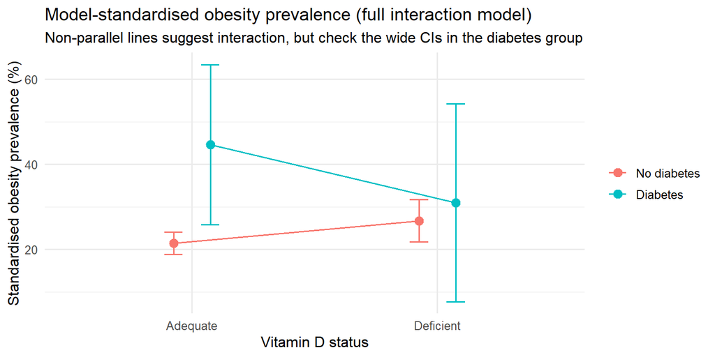

```r
# Age/sex/UPF-standardised obesity prevalence for each Vit D × diabetes combination,
# with jackknife SEs from the 60 replicate weights.
combos <- expand.grid(vitd_def = levels(d_bio$vitd_def), diabetes = levels(d_bio$diabetes))
std_prev <- withReplicates(des_bio, function(w, data) {
  data$rep_w <- w / mean(w)            # rescale to mean 1 (as svyglm does) so IRLS converges
  fit <- glm(f$P4_int, data = data, weights = rep_w, family = quasibinomial())
  sapply(seq_len(nrow(combos)), function(i) {
    nd <- data; nd$vitd_def <- combos$vitd_def[i]; nd$diabetes <- combos$diabetes[i]
    nd$vitd_def <- factor(nd$vitd_def, levels(d_bio$vitd_def))
    nd$diabetes <- factor(nd$diabetes, levels(d_bio$diabetes))
    weighted.mean(predict(fit, nd, type = "response"), w)
  })
})
combos$prev <- as.numeric(coef(std_prev)); combos$se <- as.numeric(SE(std_prev))

ggplot(combos, aes(vitd_def, 100 * prev, colour = diabetes, group = diabetes)) +
  geom_point(size = 3, position = position_dodge(0.3)) +
  geom_line(position = position_dodge(0.3)) +
  geom_errorbar(aes(ymin = 100 * (prev - 1.96 * se), ymax = 100 * (prev + 1.96 * se)),
                width = 0.15, position = position_dodge(0.3)) +
  labs(x = "Vitamin D status", y = "Standardised obesity prevalence (%)", colour = NULL,
       title = "Model-standardised obesity prevalence (full interaction model)",
       subtitle = "Non-parallel lines suggest interaction, but check the wide CIs in the diabetes group")
```

**Interpretation (auto-filled).** The interaction term was ratio of ORs = 0.39 (95% CI 0.08–1.94, p = 0.245); the LRT comparing models with and without the interaction gave p = 0.053. This is not statistically significant, so we do not have evidence that the vitamin D–obesity association differs between people with and without diabetes. Only 98 participants have diabetes, so the test has low power and the diabetic-group estimate is imprecise.

## 3.5 Model comparison and diagnostics (Week 9 summary)

```r
cmp_names <- c("P1_crude", "P1_adj", "P2_crude", "P2_adj", "P3_crude", "P3_adj", "P4_main", "P4_int")
w9 <- data.frame(Model = cmp_names,
                 Formula = sapply(f[cmp_names], function(x) deparse(x[[3]])),
                 n = sapply(uw[cmp_names], nobs),
                 AIC = round(sapply(uw[cmp_names], AIC), 1),
                 `McFadden R2` = round(sapply(uw[cmp_names], mcfadden), 3), check.names = FALSE)
w9$`ΔAIC vs best` <- round(w9$AIC - min(w9$AIC), 1)
kable(w9, caption = "Model comparison in the common biomedical sample (unweighted glm)")
```

Model comparison in the common biomedical sample (unweighted glm)

|  | Model | Formula | n | AIC | McFadden R2 | ΔAIC vs best |
| --- | --- | --- | --- | --- | --- | --- |
| P1_crude | P1_crude | vitd3 | 2617 | 3077.9 | 0.001 | 130.5 |
| P1_adj | P1_adj | vitd3 + age + sex | 2617 | 3014.4 | 0.023 | 67.0 |
| P2_crude | P2_crude | upf10 | 2617 | 3060.8 | 0.006 | 113.4 |
| P2_adj | P2_adj | upf10 + age + sex | 2617 | 2990.3 | 0.030 | 42.9 |
| P3_crude | P3_crude | vitd3 + upf10 | 2617 | 3061.8 | 0.007 | 114.4 |
| P3_adj | P3_adj | vitd3 + upf10 + age + sex | 2617 | 2987.3 | 0.032 | 39.9 |
| P4_main | P4_main | vitd_def + diabetes + upf10 + age + sex | 2617 | 2949.2 | 0.045 | 1.8 |
| P4_int | P4_int | vitd_def * diabetes + upf10 + age + sex | 2617 | 2947.4 | 0.046 | 0.0 |

```r
save_tab(w9, "week9_model_comparison")

# Nested likelihood-ratio tests along the model-building path
nested <- list(c("P1_crude", "P1_adj"), c("P2_crude", "P2_adj"), c("P1_adj", "P3_adj"),
               c("P2_adj", "P3_adj"), c("P4_main", "P4_int"))
# P3_adj vs P4_* are not nested (vitamin D is coded in 3 levels vs 2), so compare them with AIC only.
lrt_tab <- do.call(rbind, lapply(nested, function(m) {
  a <- anova(uw[[m[1]]], uw[[m[2]]], test = "LRT")
  data.frame(Comparison = paste(m[1], "→", m[2]), df = a$Df[2],
             `LR χ²` = round(a$Deviance[2], 2), p = fmt_p(a$`Pr(>Chi)`[2]), check.names = FALSE)
}))
kable(lrt_tab, caption = "Likelihood-ratio tests: does adding the extra term(s) improve fit?")
```

Likelihood-ratio tests: does adding the extra term(s) improve fit?

| Comparison | df | LR χ² | p |
| --- | --- | --- | --- |
| P1_crude → P1_adj | 2 | 67.50 | <0.001 |
| P2_crude → P2_adj | 2 | 74.42 | <0.001 |
| P1_adj → P3_adj | 1 | 29.05 | <0.001 |
| P2_adj → P3_adj | 2 | 7.03 | 0.030 |
| P4_main → P4_int | 1 | 3.76 | 0.053 |

```r
# Combined weighted OR table for the report
all_or <- or_compare(list(P1_adj = sw$P1_adj, P2_adj_full = sw$P2_adj_full,
                          P3_adj = sw$P3_adj, P4_int = sw$P4_int))
save_tab(all_or, "week9_adjusted_odds_ratios")
```

```r
# 1) Linearity of continuous terms on the logit scale: linear vs natural spline (3 df)
lin_check <- data.frame(
  Term = c("Age", "UPF proxy"),
  `LRT p (spline vs linear)` = fmt_p(c(
    anova(uw$P3_adj, glm_fit(obese ~ vitd3 + upf10 + splines::ns(age, 3) + sex, d_bio),
          test = "LRT")$`Pr(>Chi)`[2],
    anova(uw$P3_adj, glm_fit(obese ~ vitd3 + splines::ns(upf10, 3) + age + sex, d_bio),
          test = "LRT")$`Pr(>Chi)`[2])),
  check.names = FALSE)
kable(lin_check, caption = "Linearity check (p < 0.05 would suggest a non-linear term is needed)")
```

Linearity check (p < 0.05 would suggest a non-linear term is needed)

| Term | LRT p (spline vs linear) |
| --- | --- |
| Age | 0.269 |
| UPF proxy | 0.860 |

```r
# 2) Influential observations
cd <- cooks.distance(uw$P4_int)
c(`max Cook's distance` = round(max(cd), 4), `n with D > 4/n` = sum(cd > 4 / length(cd)))
```

```
## max Cook's distance      n with D > 4/n
##              0.0123             91.0000
```

## 3.6 Sensitivity analyses

1. **Prevalence ratios** (modified Poisson, log link, robust/replicate SEs) as planned in the proposal — ORs exaggerate risk ratios when the outcome is common (~27% here).
2. **Extended confounders**: + total energy, physical activity and smoking.
3. **Alternative outcome**: waist-circumference obesity (≥94 cm men, ≥80 cm women).

```r
key_terms <- c("vitd3Mild", "vitd3ModSevere", "upf10", "vitd_defDeficient",
               "diabetesDiabetes", int_term)
pull_terms <- function(fit, spec, measure) tidy_or(fit) %>% filter(term %in% key_terms) %>%
  transmute(Specification = spec, Measure = measure, Term = lab(term),
            Term = sub("ratio of ORs", paste0("ratio of ", measure, "s"), Term),
            Estimate = sprintf("%.2f (%.2f–%.2f)", est, lo, hi), p = fmt_p(p),
            unstable = hi / lo > 1000)   # flags terms that are not estimable

start_vals <- function(ff, data) c(log(mean(data$obese)), rep(0, ncol(model.matrix(ff, data)) - 1))
des_pa    <- subset(des_bio, !is.na(pa_hours) & !is.na(smoker))
des_waist <- subset(des_bio, !is.na(waist_obese))
f_ext3 <- update(f$P3_adj, . ~ . + energy_MJ + pa_hours + smoker)
f_ext4 <- update(f$P4_int, . ~ . + energy_MJ + pa_hours + smoker)

sens <- bind_rows(
  pull_terms(sw$P3_adj, "Main: P3 adjusted", "OR"),
  pull_terms(sw$P4_int, "Main: P4 interaction", "OR"),
  pull_terms(svyglm(f$P3_adj, des_bio, family = quasipoisson(link = "log"),
                    start = start_vals(f$P3_adj, d_bio)), "Modified Poisson: P3", "PR"),
  pull_terms(svyglm(f$P4_int, des_bio, family = quasipoisson(link = "log"),
                    start = start_vals(f$P4_int, d_bio)), "Modified Poisson: P4", "PR"),
  pull_terms(svyglm(f_ext3, des_pa, family = quasibinomial()), "Extended confounders: P3", "OR"),
  pull_terms(svyglm(f_ext4, des_pa, family = quasibinomial()), "Extended confounders: P4", "OR"),
  pull_terms(svyglm(update(f$P3_adj, waist_obese ~ .), des_waist, family = quasibinomial()),
             "Waist outcome: P3", "OR"),
  pull_terms(svyglm(update(f$P4_int, waist_obese ~ .), des_waist, family = quasibinomial()),
             "Waist outcome: P4", "OR"))
kable(sens %>% select(-unstable), caption = "Key estimates under alternative specifications (survey-weighted)")
```

Key estimates under alternative specifications (survey-weighted)

| Specification | Measure | Term | Estimate | p |
| --- | --- | --- | --- | --- |
| Main: P3 adjusted | OR | Vit D mild deficiency, 30–49 nmol/L (ref: adequate ≥50) | 1.03 (0.70–1.51) | 0.883 |
| Main: P3 adjusted | OR | Vit D moderate/severe deficiency, <30 nmol/L (ref: adequate) | 2.72 (1.35–5.48) | 0.006 |
| Main: P3 adjusted | OR | UPF proxy, per +10 % of energy | 1.44 (1.24–1.68) | <0.001 |
| Main: P4 interaction | OR | Vit D deficient, <50 nmol/L (ref: adequate) | 1.36 (0.98–1.89) | 0.068 |
| Main: P4 interaction | OR | Diabetes (HbA1c) (ref: no diabetes) | 3.19 (1.37–7.42) | 0.008 |
| Main: P4 interaction | OR | UPF proxy, per +10 % of energy | 1.43 (1.22–1.67) | <0.001 |
| Main: P4 interaction | OR | Interaction: Vit D deficient × Diabetes (ratio of ORs) | 0.39 (0.08–1.94) | 0.245 |
| Modified Poisson: P3 | PR | Vit D mild deficiency, 30–49 nmol/L (ref: adequate ≥50) | 1.02 (0.77–1.34) | 0.908 |
| Modified Poisson: P3 | PR | Vit D moderate/severe deficiency, <30 nmol/L (ref: adequate) | 2.00 (1.27–3.16) | 0.003 |
| Modified Poisson: P3 | PR | UPF proxy, per +10 % of energy | 1.29 (1.16–1.42) | <0.001 |
| Modified Poisson: P4 | PR | Vit D deficient, <50 nmol/L (ref: adequate) | 1.25 (0.98–1.58) | 0.070 |
| Modified Poisson: P4 | PR | Diabetes (HbA1c) (ref: no diabetes) | 1.93 (1.31–2.84) | 0.001 |
| Modified Poisson: P4 | PR | UPF proxy, per +10 % of energy | 1.28 (1.15–1.41) | <0.001 |
| Modified Poisson: P4 | PR | Interaction: Vit D deficient × Diabetes (ratio of PRs) | 0.59 (0.25–1.39) | 0.222 |
| Extended confounders: P3 | OR | Vit D mild deficiency, 30–49 nmol/L (ref: adequate ≥50) | 1.02 (0.69–1.53) | 0.910 |
| Extended confounders: P3 | OR | Vit D moderate/severe deficiency, <30 nmol/L (ref: adequate) | 2.63 (1.24–5.56) | 0.013 |
| Extended confounders: P3 | OR | UPF proxy, per +10 % of energy | 1.46 (1.24–1.72) | <0.001 |
| Extended confounders: P4 | OR | Vit D deficient, <50 nmol/L (ref: adequate) | 1.34 (0.95–1.91) | 0.098 |
| Extended confounders: P4 | OR | Diabetes (HbA1c) (ref: no diabetes) | 3.04 (1.31–7.05) | 0.010 |
| Extended confounders: P4 | OR | UPF proxy, per +10 % of energy | 1.44 (1.22–1.70) | <0.001 |
| Extended confounders: P4 | OR | Interaction: Vit D deficient × Diabetes (ratio of ORs) | 0.44 (0.09–2.17) | 0.304 |
| Waist outcome: P3 | OR | Vit D mild deficiency, 30–49 nmol/L (ref: adequate ≥50) | 1.29 (0.86–1.93) | 0.211 |
| Waist outcome: P3 | OR | Vit D moderate/severe deficiency, <30 nmol/L (ref: adequate) | 2.46 (1.24–4.89) | 0.011 |
| Waist outcome: P3 | OR | UPF proxy, per +10 % of energy | 1.30 (1.14–1.48) | <0.001 |
| Waist outcome: P4 | OR | Vit D deficient, <50 nmol/L (ref: adequate) | 1.44 (0.96–2.17) | 0.076 |
| Waist outcome: P4 | OR | Diabetes (HbA1c) (ref: no diabetes) | 3.77 (1.08–13.09) | 0.037 |
| Waist outcome: P4 | OR | UPF proxy, per +10 % of energy | 1.29 (1.13–1.48) | <0.001 |
| Waist outcome: P4 | OR | Interaction: Vit D deficient × Diabetes (ratio of ORs) | 3.01 (0.00–91600351676.42) | 0.927 |

```r
save_tab(sens, "week9_sensitivity")
waist_cells <- with(subset(d_bio, !is.na(waist_obese)),
                    table(VitD = vitd_def, Diabetes = diabetes, `Waist obese` = waist_obese))
```

**Note:** the following estimate(s) have extremely wide CIs and should be reported as *not estimable*: Waist outcome: P4 – Interaction: Vit D deficient × Diabetes (ratio of ORs). For the waist outcome this is quasi-complete separation: almost everyone with diabetes meets the waist threshold (only 1 vitamin D-deficient participant(s) with diabetes are below it).

# 4 Week 10 – Testing the prediction of the models

Prediction is assessed on the common biomedical sample (n = 2617) with unweighted models, because the question is how well each model classifies *individuals*.

- **Hold-out test:** stratified 70/30 train/test split; models are fitted on the training set and scored on the test set.
- **Repeated 10-fold cross-validation** (5 repeats) gives a more stable estimate of out-of-sample AUC and Brier score.
- **Metrics:** AUC (discrimination, DeLong 95% CI), Brier score (overall accuracy of probabilities), sensitivity, specificity, PPV, NPV and accuracy. The classification threshold is chosen on the *training* data (Youden index) to avoid leakage. Calibration is checked with the Hosmer–Lemeshow test and a calibration plot.
- **Other methods:** LDA, a classification tree and k-nearest neighbours, plus **K-means** clustering (unsupervised).

```r
d_pred <- d_bio
idx_train <- unlist(lapply(split(seq_len(nrow(d_pred)), d_pred$obese),
                           function(i) sample(i, round(0.7 * length(i)))))
train <- d_pred[idx_train, ]; test <- d_pred[-idx_train, ]
kable(data.frame(Set = c("Train", "Test"), n = c(nrow(train), nrow(test)),
                 `Obese %` = round(100 * c(mean(train$obese), mean(test$obese)), 1), check.names = FALSE),
      caption = "Stratified 70/30 split")
```

Stratified 70/30 split

| Set | n | Obese % |
| --- | --- | --- |
| Train | 1832 | 27.5 |
| Test | 785 | 27.4 |

```r
f_pred <- c(list(M0_AgeSex = obese ~ age + sex), f[cmp_names])
```

## 4.1 Hold-out test-set performance

```r
eval_model <- function(ff, name) {
  fit   <- glm(ff, data = train, family = binomial)
  p_tr  <- predict(fit, train, type = "response")
  p_te  <- predict(fit, test,  type = "response")
  thr   <- pROC::coords(mk_roc(train$obese, p_tr), "best", best.method = "youden",
                        ret = "threshold", transpose = FALSE)$threshold[1]
  r     <- mk_roc(test$obese, p_te); ci <- pROC::ci.auc(r)
  pred  <- as.integer(p_te >= thr); y <- test$obese
  tp <- sum(pred == 1 & y == 1); tn <- sum(pred == 0 & y == 0)
  fp <- sum(pred == 1 & y == 0); fn <- sum(pred == 0 & y == 1)
  list(roc = r, p = p_te,
       row = data.frame(Model = name,
                        AUC = sprintf("%.3f (%.3f–%.3f)", ci[2], ci[1], ci[3]), AUC_num = ci[2],
                        Brier = round(brier(y, p_te), 4), Threshold = round(thr, 3),
                        Sensitivity = round(tp / (tp + fn), 3), Specificity = round(tn / (tn + fp), 3),
                        PPV = round(tp / max(tp + fp, 1), 3), NPV = round(tn / max(tn + fn, 1), 3),
                        Accuracy = round((tp + tn) / length(y), 3),
                        `Accuracy @0.5` = round(mean(as.integer(p_te >= 0.5) == y), 3),
                        check.names = FALSE))
}
ho <- lapply(names(f_pred), function(m) eval_model(f_pred[[m]], m)); names(ho) <- names(f_pred)
ho_tab <- bind_rows(lapply(ho, `[[`, "row"))
kable(ho_tab %>% select(-AUC_num), caption = sprintf(
  "Test-set performance (no-information accuracy = %.3f, i.e. always predicting 'not obese')",
  1 - mean(test$obese)))
```

Test-set performance (no-information accuracy = 0.726, i.e. always predicting ‘not obese’)

| Model | AUC | Brier | Threshold | Sensitivity | Specificity | PPV | NPV | Accuracy | Accuracy @0.5 |
| --- | --- | --- | --- | --- | --- | --- | --- | --- | --- |
| M0_AgeSex | 0.583 (0.539–0.626) | 0.1955 | 0.250 | 0.670 | 0.437 | 0.310 | 0.778 | 0.501 | 0.726 |
| P1_crude | 0.506 (0.472–0.540) | 0.1991 | 0.298 | 0.195 | 0.814 | 0.284 | 0.728 | 0.645 | 0.726 |
| P1_adj | 0.580 (0.537–0.623) | 0.1962 | 0.299 | 0.433 | 0.639 | 0.311 | 0.749 | 0.582 | 0.726 |
| P2_crude | 0.549 (0.503–0.594) | 0.1979 | 0.270 | 0.526 | 0.544 | 0.303 | 0.752 | 0.539 | 0.726 |
| P2_adj | 0.600 (0.556–0.644) | 0.1938 | 0.253 | 0.647 | 0.493 | 0.325 | 0.787 | 0.535 | 0.726 |
| P3_crude | 0.543 (0.497–0.588) | 0.1981 | 0.285 | 0.400 | 0.667 | 0.312 | 0.747 | 0.594 | 0.726 |
| P3_adj | 0.601 (0.557–0.644) | 0.1943 | 0.236 | 0.721 | 0.435 | 0.325 | 0.805 | 0.513 | 0.727 |
| P4_main | 0.612 (0.568–0.656) | 0.1920 | 0.227 | 0.712 | 0.425 | 0.318 | 0.796 | 0.503 | 0.734 |
| P4_int | 0.612 (0.568–0.657) | 0.1914 | 0.231 | 0.693 | 0.437 | 0.317 | 0.790 | 0.507 | 0.732 |

```r
save_tab(ho_tab, "week10_holdout_performance")
```

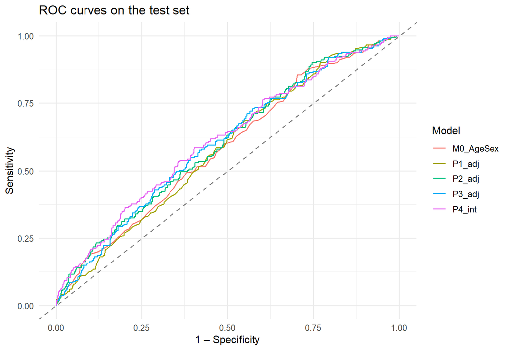

```r
sel <- c("M0_AgeSex", "P1_adj", "P2_adj", "P3_adj", "P4_int")
pROC::ggroc(lapply(ho[sel], `[[`, "roc"), legacy.axes = TRUE) +
  geom_abline(linetype = "dashed", colour = "grey50") +
  labs(title = "ROC curves on the test set", colour = "Model",
       x = "1 – Specificity", y = "Sensitivity")
```

```r
delong <- do.call(rbind, lapply(setdiff(names(ho), "M0_AgeSex"), function(m) {
  t <- pROC::roc.test(ho$M0_AgeSex$roc, ho[[m]]$roc, method = "delong", paired = TRUE)
  data.frame(Comparison = paste(m, "vs M0_AgeSex"),
             `ΔAUC` = round(as.numeric(pROC::auc(ho[[m]]$roc) - pROC::auc(ho$M0_AgeSex$roc)), 3),
             p = fmt_p(t$p.value), check.names = FALSE)
}))
t34 <- pROC::roc.test(ho$P3_adj$roc, ho$P4_int$roc, method = "delong", paired = TRUE)
delong <- rbind(delong, data.frame(Comparison = "P4_int vs P3_adj",
  `ΔAUC` = round(as.numeric(pROC::auc(ho$P4_int$roc) - pROC::auc(ho$P3_adj$roc)), 3),
  p = fmt_p(t34$p.value), check.names = FALSE))
kable(delong, caption = "DeLong tests: do the exposures improve discrimination beyond age and sex?")
```

DeLong tests: do the exposures improve discrimination beyond age and sex?

| Comparison | ΔAUC | p |
| --- | --- | --- |
| P1_crude vs M0_AgeSex | -0.077 | 0.009 |
| P1_adj vs M0_AgeSex | -0.003 | 0.755 |
| P2_crude vs M0_AgeSex | -0.034 | 0.321 |
| P2_adj vs M0_AgeSex | 0.018 | 0.189 |
| P3_crude vs M0_AgeSex | -0.040 | 0.244 |
| P3_adj vs M0_AgeSex | 0.018 | 0.226 |
| P4_main vs M0_AgeSex | 0.030 | 0.077 |
| P4_int vs M0_AgeSex | 0.030 | 0.078 |
| P4_int vs P3_adj | 0.012 | 0.087 |

## 4.2 Repeated 10-fold cross-validation

```r
K <- 10; R <- 5
cv_res <- list()
for (r in seq_len(R)) {
  folds <- integer(nrow(d_pred))
  for (cls in 0:1) {                                   # stratified fold assignment
    ii <- which(d_pred$obese == cls)
    folds[ii] <- sample(rep(seq_len(K), length.out = length(ii)))
  }
  for (k in seq_len(K)) {
    tr <- d_pred[folds != k, ]; te <- d_pred[folds == k, ]
    for (m in names(f_pred)) {
      fit <- glm(f_pred[[m]], data = tr, family = binomial)
      p   <- predict(fit, te, type = "response")
      cv_res[[length(cv_res) + 1]] <- data.frame(model = m, rep = r, fold = k,
        auc = as.numeric(pROC::auc(mk_roc(te$obese, p))), brier = brier(te$obese, p))
    }
  }
}
cv_sum <- bind_rows(cv_res) %>% group_by(Model = model) %>%
  summarise(`CV AUC mean` = round(mean(auc), 3), `CV AUC SD` = round(sd(auc), 3),
            `CV Brier mean` = round(mean(brier), 4), .groups = "drop") %>%
  arrange(desc(`CV AUC mean`))
kable(cv_sum, caption = sprintf("%d × %d-fold cross-validation (null-model Brier = %.4f)",
                                R, K, mean(d_pred$obese) * (1 - mean(d_pred$obese))))
```

5 × 10-fold cross-validation (null-model Brier = 0.1991)

| Model | CV AUC mean | CV AUC SD | CV Brier mean |
| --- | --- | --- | --- |
| P4_int | 0.636 | 0.031 | 0.1892 |
| P4_main | 0.636 | 0.032 | 0.1893 |
| P3_adj | 0.618 | 0.036 | 0.1926 |
| P2_adj | 0.615 | 0.036 | 0.1929 |
| M0_AgeSex | 0.597 | 0.036 | 0.1947 |
| P1_adj | 0.597 | 0.035 | 0.1945 |
| P2_crude | 0.552 | 0.039 | 0.1978 |
| P3_crude | 0.551 | 0.040 | 0.1979 |
| P1_crude | 0.510 | 0.027 | 0.1991 |

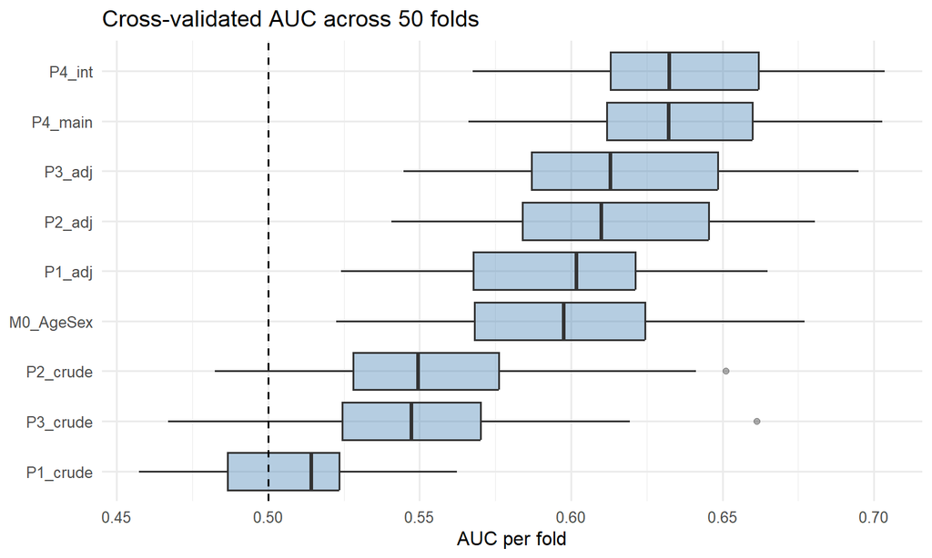

```r
save_tab(cv_sum, "week10_cross_validation")

ggplot(bind_rows(cv_res), aes(reorder(model, auc), auc)) +
  geom_boxplot(fill = "steelblue", alpha = 0.4) + coord_flip() +
  geom_hline(yintercept = 0.5, linetype = "dashed") +
  labs(x = NULL, y = "AUC per fold", title = "Cross-validated AUC across 50 folds")
```

## 4.3 Calibration of the full model (P4_int)

```r
p_full <- ho$P4_int$p
hl <- hosmer_lemeshow(test$obese, p_full)
cal_fit <- glm(test$obese ~ qlogis(p_full), family = binomial)
cal_int <- glm(test$obese ~ offset(qlogis(p_full)), family = binomial)
kable(data.frame(Statistic = c("Hosmer–Lemeshow χ²", "HL df", "HL p-value",
                               "Calibration slope (ideal 1)", "Calibration-in-the-large (ideal 0)"),
                 Value = unname(c(round(hl[1], 2), hl[2], fmt_p(hl[3]),
                                  round(coef(cal_fit)[2], 3), round(coef(cal_int)[1], 3)))),
      caption = "Calibration on the test set")
```

Calibration on the test set

| Statistic | Value |
| --- | --- |
| Hosmer–Lemeshow χ² | 4.8 |
| HL df | 8 |
| HL p-value | 0.779 |
| Calibration slope (ideal 1) | 0.825 |
| Calibration-in-the-large (ideal 0) | 0.02 |

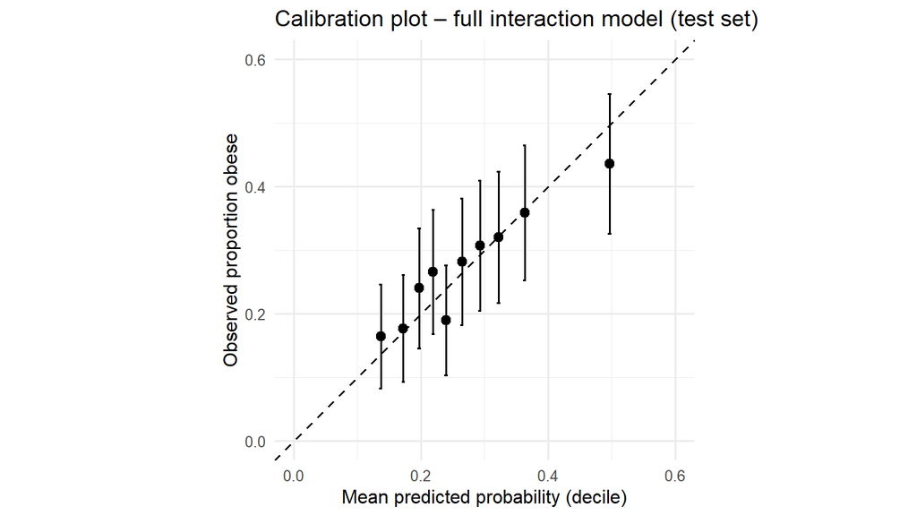

```r
cal_df <- data.frame(y = test$obese, p = p_full) %>%
  mutate(bin = ntile(p, 10)) %>% group_by(bin) %>%
  summarise(pred = mean(p), obs = mean(y), n = n(), .groups = "drop") %>%
  mutate(se = sqrt(obs * (1 - obs) / n))
ggplot(cal_df, aes(pred, obs)) +
  geom_abline(linetype = "dashed") + geom_point(size = 2.5) +
  geom_errorbar(aes(ymin = pmax(obs - 1.96 * se, 0), ymax = pmin(obs + 1.96 * se, 1)), width = 0.005) +
  coord_equal(xlim = c(0, 0.6), ylim = c(0, 0.6)) +
  labs(x = "Mean predicted probability (decile)", y = "Observed proportion obese",
       title = "Calibration plot – full interaction model (test set)")
```

## 4.4 Comparison with other classification methods

Same predictors as the full model (Vit D deficiency, diabetes, UPF, age, sex). The tree uses equal priors so it does not collapse to “everyone not obese”; the kNN `k` is tuned by leave-one-out CV on the training set.

```r
xvars <- function(d) data.frame(age = d$age, upf = d$upf,
                                vitd_def = as.integer(d$vitd_def == "Deficient"),
                                diabetes = as.integer(d$diabetes == "Diabetes"),
                                female = as.integer(d$sex == "Female"))
Xtr <- xvars(train); Xte <- xvars(test)
mu <- colMeans(Xtr); sdv <- apply(Xtr, 2, sd)
Ztr <- scale(Xtr, mu, sdv); Zte <- scale(Xte, mu, sdv)
f_x <- obese_f ~ vitd_def + diabetes + upf10 + age + sex

# Linear discriminant analysis
lda_fit <- MASS::lda(f_x, data = train)
p_lda   <- predict(lda_fit, test)$posterior[, "Obese"]

# Classification tree, pruned at the CV-optimal complexity
tree <- rpart::rpart(f_x, data = train, method = "class", parms = list(prior = c(0.5, 0.5)),
                     control = rpart::rpart.control(cp = 0.001, xval = 10, minbucket = 20))
best_cp <- tree$cptable[which.min(tree$cptable[, "xerror"]), "CP"]
tree_p  <- rpart::prune(tree, cp = best_cp)
p_tree  <- predict(tree_p, test, type = "prob")[, "Obese"]

# k-nearest neighbours, k tuned by LOOCV AUC on the training data
knn_prob <- function(pred) ifelse(pred == "1", attr(pred, "prob"), 1 - attr(pred, "prob"))
k_grid <- seq(5, 95, by = 10)
k_auc  <- sapply(k_grid, function(k) as.numeric(pROC::auc(mk_roc(train$obese,
            knn_prob(class::knn.cv(Ztr, factor(train$obese), k = k, prob = TRUE))))))
k_best <- k_grid[which.max(k_auc)]
p_knn  <- knn_prob(class::knn(Ztr, Zte, factor(train$obese), k = k_best, prob = TRUE))

methods <- list(ho$P4_int$p, p_lda, p_tree, p_knn)
names(methods) <- c("Logistic (P4_int)", "LDA", "Classification tree", paste0("kNN (k=", k_best, ")"))
meth_tab <- bind_rows(lapply(names(methods), function(m) {
  r <- mk_roc(test$obese, methods[[m]]); ci <- pROC::ci.auc(r)
  data.frame(Method = m, AUC = sprintf("%.3f (%.3f–%.3f)", ci[2], ci[1], ci[3]),
             Brier = round(brier(test$obese, methods[[m]]), 4))
}))
kable(meth_tab, caption = "Test-set comparison of classification methods")
```

Test-set comparison of classification methods

| Method | AUC | Brier |
| --- | --- | --- |
| Logistic (P4_int) | 0.612 (0.568–0.657) | 0.1914 |
| LDA | 0.613 (0.569–0.657) | 0.1923 |
| Classification tree | 0.560 (0.521–0.599) | 0.2493 |
| kNN (k=95) | 0.603 (0.559–0.648) | 0.1928 |

```r
save_tab(meth_tab, "week10_method_comparison")
```

## 4.5 K-means clustering

K-means is **unsupervised**: it groups people by similarity in their characteristics without using obesity. We use it in three ways: (a) to see whether natural age–diet profiles in the data line up with obesity, (b) as a crude predictor (cluster membership) compared against the logistic model, and (c) to split the logistic model’s predicted risks into low/medium/high groups as a check of risk stratification.

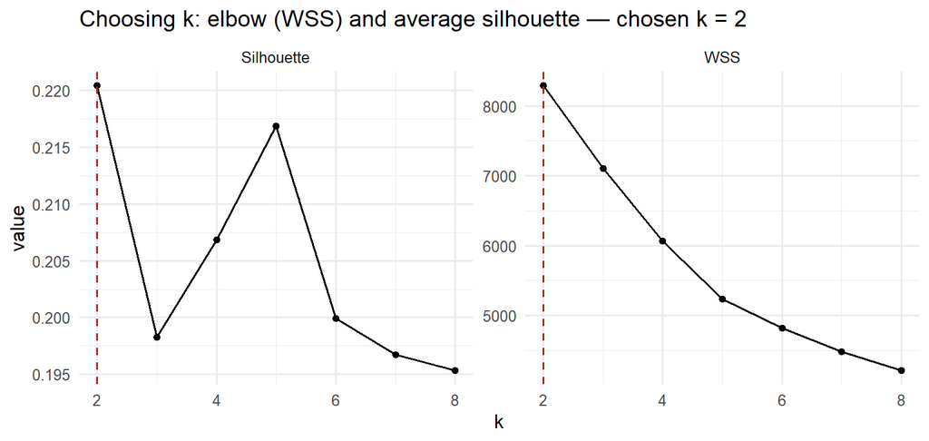

```r
# Continuous inputs only: K-means uses Euclidean distance, so a 3-level variable such as
# vitamin D would dominate the solution (clusters would just reproduce the vitamin D groups).
# Clusters are therefore "age-diet profiles"; vitamin D, diabetes and obesity are compared afterwards.
km_vars <- c("age", "SATPER1", "PEADDSD1", "energy_MJ")
Zall <- scale(d_pred[, km_vars])
k_try <- 2:8
wss <- sapply(k_try, function(k) kmeans(Zall, k, nstart = 25, iter.max = 50)$tot.withinss)
dmat <- dist(Zall)
sil <- sapply(k_try, function(k) {
  km <- kmeans(Zall, k, nstart = 25, iter.max = 50)
  mean(cluster::silhouette(km$cluster, dmat)[, "sil_width"])
})
k_opt <- k_try[which.max(sil)]
data.frame(k = k_try, WSS = wss, Silhouette = sil) %>%
  pivot_longer(-k) %>%
  ggplot(aes(k, value)) + geom_line() + geom_point() +
  facet_wrap(~name, scales = "free_y") +
  geom_vline(xintercept = k_opt, linetype = "dashed", colour = "firebrick") +
  labs(title = sprintf("Choosing k: elbow (WSS) and average silhouette — chosen k = %d", k_opt))
```

```r
km <- kmeans(Zall, k_opt, nstart = 50, iter.max = 100)
d_pred$cluster <- factor(km$cluster)

prof <- d_pred %>% group_by(Cluster = cluster) %>%
  summarise(n = n(), `Mean age` = round(mean(age), 1),
            `Sat/trans fat %E` = round(mean(SATPER1), 1), `Added sugar %E` = round(mean(PEADDSD1), 1),
            `Energy MJ/day` = round(mean(energy_MJ), 1),
            `Vit D deficient %` = round(100 * mean(vitd_def == "Deficient"), 1),
            `Female %` = round(100 * mean(sex == "Female"), 1),
            `Diabetes %` = round(100 * mean(diabetes == "Diabetes"), 1),
            `Obese %` = round(100 * mean(obese), 1), .groups = "drop")
chi <- chisq.test(table(d_pred$cluster, d_pred$obese))
kable(prof, caption = sprintf("Cluster profiles (χ² test of obesity across clusters: p = %s; adjusted Rand index vs obesity = %.3f)",
                              fmt_p(chi$p.value), adj_rand(d_pred$cluster, d_pred$obese)))
```

Cluster profiles (χ² test of obesity across clusters: p = 0.001; adjusted Rand index vs obesity = -0.004)

| Cluster | n | Mean age | Sat/trans fat %E | Added sugar %E | Energy MJ/day | Vit D deficient % | Female % | Diabetes % | Obese % |
| --- | --- | --- | --- | --- | --- | --- | --- | --- | --- |
| 1 | 1478 | 51.1 | 11.2 | 6.2 | 7.9 | 20.1 | 58.5 | 5.5 | 30.0 |
| 2 | 1139 | 35.4 | 13.9 | 13.2 | 10.7 | 27.0 | 50.1 | 1.5 | 24.1 |

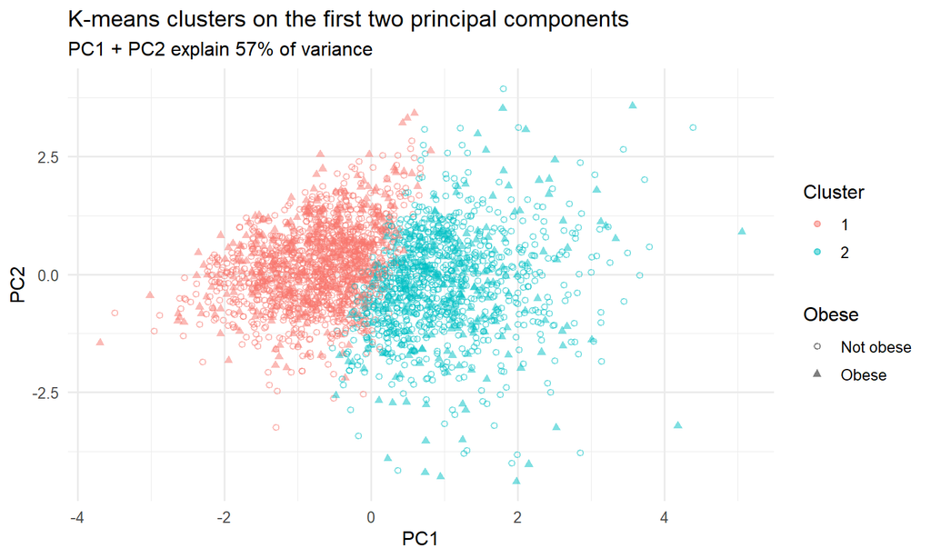

```r
save_tab(prof, "week10_kmeans_profiles")

pc <- prcomp(Zall)
data.frame(PC1 = pc$x[, 1], PC2 = pc$x[, 2], Cluster = d_pred$cluster, Obese = d_pred$obese_f) %>%
  ggplot(aes(PC1, PC2, colour = Cluster, shape = Obese)) +
  geom_point(alpha = 0.5) + scale_shape_manual(values = c(1, 17)) +
  labs(title = "K-means clusters on the first two principal components",
       subtitle = sprintf("PC1 + PC2 explain %.0f%% of variance",
                          100 * sum(pc$sdev[1:2]^2) / sum(pc$sdev^2)))
```

```r
# (b) Cluster membership as a predictor: fit K-means on the TRAINING data only,
#     assign test cases to the nearest centroid, then compare test AUC with the logistic model.
mu_k <- colMeans(train[, km_vars]); sd_k <- apply(train[, km_vars], 2, sd)
Ztr_k <- scale(train[, km_vars], mu_k, sd_k); Zte_k <- scale(test[, km_vars], mu_k, sd_k)
km_tr <- kmeans(Ztr_k, k_opt, nstart = 50, iter.max = 100)
nearest <- function(Z, centers) apply(Z, 1, function(z) which.min(colSums((t(centers) - z)^2)))
train$cl <- factor(km_tr$cluster, levels = seq_len(k_opt))
test$cl  <- factor(nearest(Zte_k, km_tr$centers), levels = seq_len(k_opt))
cl_fit <- glm(obese ~ cl, data = train, family = binomial)
p_cl   <- predict(cl_fit, test, type = "response")

# (c) K-means on the model's predicted risk → three risk groups; observed obesity should rise across groups
risk_km <- kmeans(ho$P4_int$p, centers = 3, nstart = 25)
ord <- order(risk_km$centers)
risk_grp <- factor(match(risk_km$cluster, ord), 1:3, c("Low", "Medium", "High"))
risk_tab <- data.frame(group = risk_grp, y = test$obese, p = ho$P4_int$p) %>%
  group_by(`Risk group (K-means on predicted risk)` = group) %>%
  summarise(n = n(), `Mean predicted %` = round(100 * mean(p), 1),
            `Observed obese %` = round(100 * mean(y), 1), .groups = "drop")

kable(data.frame(Predictor = c("K-means cluster membership", "Logistic regression (P4_int)"),
                 `Test AUC` = round(c(as.numeric(pROC::auc(mk_roc(test$obese, p_cl))),
                                      as.numeric(pROC::auc(ho$P4_int$roc))), 3),
                 check.names = FALSE),
      caption = "Does unsupervised clustering predict obesity as well as the supervised model?")
```

Does unsupervised clustering predict obesity as well as the supervised model?

| Predictor | Test AUC |
| --- | --- |
| K-means cluster membership | 0.518 |
| Logistic regression (P4_int) | 0.612 |

```r
kable(risk_tab, caption = "Risk stratification of the test set using K-means on predicted probabilities")
```

Risk stratification of the test set using K-means on predicted probabilities

| Risk group (K-means on predicted risk) | n | Mean predicted % | Observed obese % |
| --- | --- | --- | --- |
| Low | 432 | 19.9 | 21.1 |
| Medium | 316 | 33.0 | 32.9 |
| High | 37 | 59.0 | 54.1 |

# 5 Summary of findings (auto-filled)

**Week 9 – significance**

- **Vitamin D (Person 1):** adjusted OR = 2.46 (95% CI 1.23–4.95, p = 0.012) for moderate/severe deficiency vs adequate; overall vitamin D effect statistically significant (joint p = 0.032).
- **UPF proxy (Person 2):** adjusted OR = 1.20 (95% CI 1.12–1.30, p = <0.001) per +10 %E (full sample).
- **Both (Person 3):** vitamin D OR = 2.72 (95% CI 1.35–5.48, p = 0.006); UPF OR = 1.44 (95% CI 1.24–1.68, p = <0.001).
- **Interaction (Person 4):** ratio of ORs = 0.39 (95% CI 0.08–1.94, p = 0.245) — not statistically significant (unweighted LRT p = 0.053).
- Lowest AIC: **P4_int**.

**Week 10 – prediction**

- Best cross-validated model: **P4_int**. Age + sex alone gave CV AUC = 0.597; the full model gave CV AUC = 0.636 (*modest* discrimination). The exposures are associated with obesity at the population level, but they are weak tools for predicting whether an individual is obese.
- Accuracy at a 0.5 threshold is close to the no-information rate (0.726) because obesity is the minority class; this is why threshold-free metrics (AUC, Brier) and a Youden threshold are reported.
- Calibration of the full model: Hosmer–Lemeshow p = 0.779, slope = 0.82.
- K-means (k = 2) produced clusters with obesity prevalence ranging from 24.1% to 30% (χ² p = 0.001), but cluster membership gave a test AUC of 0.518 versus 0.612 for the logistic model, as expected for a method that never sees the outcome.

**Limitations to discuss:** cross-sectional data (reverse causation, especially obesity → low vitamin D); the UPF proxy is nutrient-based and from a single 24-hour recall; only 98 participants with diabetes (low power for the interaction); complete-case analysis restricted to biomedical participants; the full-sample design has no replicate weights, so its SEs may be slightly underestimated.

```
## Tables saved to: C:\Users\dell\Desktop\q2_outputs
```